# EDA

Michael Raffelsberger

June 22, 2021

**I have edited and extended my exploratory data analysis (EDA) from A4 to find out what variables are most promising (reliable values, not too many missing values, etc.) to use in the dashboard and what preprocessing steps have to be conducted (replace missing values, erroneous values, etc.).**

```r
library(readr)
library(dplyr)
library(tidyr)
library(ggplot2)
library(rjson)
```

```r
data <- read_csv('../data/owid-covid-data.csv')
geodata <- fromJSON(file = '../data/world_countries.json')
```

# 1 Functions

```r
count_missing <- function(x) {

  return(sum(is.na(x)))

}
```

```r
get_missing_by_date <- function(data, columns) {

  missing_by_date <- data %>%
    group_by(date) %>%
    summarize(across(all_of(columns), count_missing))

  return(missing_by_date)

}
```

```r
get_missing_by_country <- function(data, columns) {

  missing_by_country <- data %>%
    select(-date) %>%
    group_by(location) %>%
    summarize_all(count_missing)

  missing_by_country['total'] <- rowSums(missing_by_country[, 3:ncol(missing_by_country)])
  missing_by_country <- missing_by_country %>%
    arrange(desc(total))

  return(missing_by_country)

}
```

```r
plot_missing_by_date <- function(data, columns) {

  missing_by_date <- get_missing_by_date(data, columns) %>%
    pivot_longer(columns)

  ggplot() +
    geom_line(data = missing_by_date, aes(x = date, y = value)) +
    facet_wrap(~ name) +
    theme_minimal() +
    labs(x = "date", y = 'missing values')

}
```

```r
plot_missing_by_date_context <- function(data, columns) {

  missing_by_date <- get_missing_by_date(data, columns) %>%
    pivot_longer(columns)

  ggplot() +
    geom_line(data = missing_by_date, aes(x = date, y = value, color = name)) +
    geom_line(aes(x = as.Date(names(table(data$date))), y = unname(table(data$date)))) +
    theme_minimal() +
    labs(x = 'date', y = 'missing values', title = "Missings with number of rows per date") +
    theme(legend.position = 'bottom', legend.title = element_blank())

}
```

```r
plot_missing_by_country <- function(data, columns, max_plot = 10) {

  missing <- get_missing_by_country(data, columns) %>%
    slice(1:max_plot) %>%
    pivot_longer(c(columns, 'total'))

  ggplot(missing) +
    geom_col(aes(x = location, y = value)) +
    facet_wrap(~ name) +
    labs(y = 'missing values') +
    coord_flip() +
    theme_minimal()

}
```

```r
find_value_missing_transitions <- function(vec) {

  if (all(is.na(vec))) {

    return(rep(0, length(vec)))

  } else {

    weight <- 10*max(abs(vec), na.rm = TRUE)
    vec <- replace_na(vec, weight)
    diff_vec <- c(0, diff(vec))
    diff_vec[diff_vec < weight/2] <- 0
    diff_vec[diff_vec > weight/2] <- 1

    return(diff_vec)

  }

}
```

```r
show_transitions <- function(data, columns) {

  data <- data %>%
    group_by(location) %>%
    mutate_at(columns, find_value_missing_transitions) %>%
    filter(if_any(columns, function(x) x == 1))

  return(data)

}
```

```r
plot_variable <- function(data, column) {

  ggplot(data) +
    geom_line(aes(x = date, y = !!sym(column), by = location), size = 0.05) +
    theme_minimal()

}
```

```r
get_countries_from_geodata <- function(geodata) {

  countries <- sapply(geodata[[2]], function(x) unname(x[[2]][[1]]))
  return(countries)

}
```

```r
get_countries_from_data <- function(data) {

  return(unique(data$location))

}
```

# 2 Countries

**First of all we would like to harmonize the country names from the owid-covid data and the json data for the choropleth map.**

```r
json_countries <- get_countries_from_geodata(geodata)
data_countries <- get_countries_from_data(data)
```

**Some countries from the json file are not in the owid-covid data …**

```r
setdiff(json_countries, data_countries) # in json not in owid-covid
```

```
##  [1] "Antarctica"                          "French Southern and Antarctic Lands"
##  [3] "The Bahamas"                         "Ivory Coast"
##  [5] "Democratic Republic of the Congo"    "Republic of the Congo"
##  [7] "Czech Republic"                      "England"
##  [9] "Guinea Bissau"                       "Macedonia"
## [11] "Puerto Rico"                         "North Korea"
## [13] "Western Sahara"                      "Somaliland"
## [15] "Republic of Serbia"                  "Swaziland"
## [17] "East Timor"                          "United Republic of Tanzania"
## [19] "USA"                                 "West Bank"
```

**… and the other way round.**

```r
setdiff(data_countries, json_countries) # in owid-covid not in json
```

```
##  [1] "Africa"                           "Andorra"
##  [3] "Anguilla"                         "Antigua and Barbuda"
##  [5] "Aruba"                            "Asia"
##  [7] "Bahamas"                          "Bahrain"
##  [9] "Barbados"                         "Bermuda"
## [11] "Bonaire Sint Eustatius and Saba"  "British Virgin Islands"
## [13] "Cape Verde"                       "Cayman Islands"
## [15] "Comoros"                          "Congo"
## [17] "Cook Islands"                     "Cote d'Ivoire"
## [19] "Curacao"                          "Czechia"
## [21] "Democratic Republic of Congo"     "Dominica"
## [23] "Eswatini"                         "Europe"
## [25] "European Union"                   "Faeroe Islands"
## [27] "French Polynesia"                 "Gibraltar"
## [29] "Grenada"                          "Guernsey"
```

[output cut: 22 more lines]

**We can harmonize some of them. Unfortunately UK/England is a problematic case. Some small countries have covid data but do not play a role on the map. Some countries are on the map but do not have covid data since they are not officially states (e.g. Western Sahara, Antarctica) for instance.**

```r
country_dict <- list(
  # Antarctica,
  # French Southern and Antarctic Lands,
  "Bahamas" = "The Bahamas",
  "Cote d'Ivoire" = "Ivory Coast",
  "Democratic Republic of Congo" = "Democratic Republic of the Congo",
  "Congo" = "Republic of the Congo",
  "Czechia" = "Czech Republic",
  # "United Kingdom" = "England",
  "Guinea-Bissau" = "Guinea Bissau",
  "North Macedonia" = "Macedonia",
  # Puerto Rico,
  # North Korea,
  # Western Sahara,
  # Somaliland,
  "Serbia" = "Republic of Serbia",
  # Swaziland,
  # East Timor,
  "Tanzania" = "United Republic of Tanzania",
  "United States" = "USA"
  # "Palestine" = "West Bank"
)

country_dict_vec <- as.character(country_dict)
names(country_dict_vec) <- names(country_dict)
```

**We filter the country where we can use both the covid data and the map.**

```r
data <- data %>%
  mutate(location = recode(location, !!!country_dict_vec)) %>%
  filter(location %in% c(json_countries, "World"))
```

# 3 Features

**The next step is to have a look at the codebook (https://github.com/owid/covid-19-data/blob/master/public/data/owid-covid-codebook.csv) and get an idea of what variables might play a role in our analysis. There are a handful of relevant groups of features for the task. The first group consists of some identifiers or general country specific information. The core covid data are the groups of infection, death, vaccination and test columns. Furthermore, we have risk factor columns as well as fact columns (for the fact fields) that will be relevant for the dashboard.**

**We look at the number of missing values per column to make sure we do not choose the ‘worst’ columns. Relative columns (per million, per thousand, etc.) have the same amount of missing values as their corresponding absolute columns. ICU has a lot of missing values which is why I decided to leave it out to save some effort.**

```r
sort(sapply(data, count_missing))
```

```
##                              iso_code                              location
##                                     0                                     0
##                                  date                            population
##                                     0                                   134
##                             continent                       life_expectancy
##                                   496                                   578
##                 cardiovasc_death_rate                            median_age
##                                   758                                   770
##                           total_cases               total_cases_per_million
##                                   943                                   943
##                             new_cases                 new_cases_per_million
##                                   949                                   949
##                         aged_70_older                    population_density
##                                  1231                                  1561
##                   diabetes_prevalence                         aged_65_older
##                                  1583                                  1708
##                    new_cases_smoothed                   new_deaths_smoothed
##                                  1764                                  1764
##        new_cases_smoothed_per_million       new_deaths_smoothed_per_million
##                                  1764                                  1764
##               human_development_index                        gdp_per_capita
##                                  1827                                  2265
##                      stringency_index                          total_deaths
##                                  4128                                  6872
##              total_deaths_per_million                            new_deaths
##                                  6872                                  6873
##                new_deaths_per_million                     reproduction_rate
##                                  6873                                  7850
##            hospital_beds_per_thousand                        female_smokers
##                                  8156                                 15374
##                          male_smokers                       extreme_poverty
##                                 16333                                 21913
##                           tests_units                    new_tests_smoothed
##                                 28689                                 29923
##       new_tests_smoothed_per_thousand                         positive_rate
##                                 29923                                 32259
##                        tests_per_case                           total_tests
##                                 32791                                 35449
##              total_tests_per_thousand                             new_tests
##                                 35449                                 35542
##                new_tests_per_thousand                handwashing_facilities
##                                 35542                                 35871
##             new_vaccinations_smoothed new_vaccinations_smoothed_per_million
##                                 58024                                 58024
##                    total_vaccinations        total_vaccinations_per_hundred
##                                 64556                                 64556
##                     people_vaccinated         people_vaccinated_per_hundred
##                                 65313                                 65313
##                      new_vaccinations               people_fully_vaccinated
##                                 66145                                 67410
##   people_fully_vaccinated_per_hundred                          icu_patients
##                                 67410                                 74575
##              icu_patients_per_million                         hosp_patients
##                                 74575                                 74575
##             hosp_patients_per_million                 weekly_icu_admissions
##                                 74575                                 74575
##     weekly_icu_admissions_per_million                weekly_hosp_admissions
##                                 74575                                 74575
##    weekly_hosp_admissions_per_million
##                                 74575
```

```r
identifier_columns <- c(
  'location',
  'date'
)

infection_columns <- c(
  'total_cases_per_million', # interesting for risk/development factors
  'new_cases_per_million', # interesting for vaccination
  'new_cases_smoothed_per_million' # interesting for vaccination
)

death_columns <- c(
  'new_deaths_smoothed_per_million',
  'total_deaths_per_million',
  'new_deaths_per_million'
)

vaccination_columns <- c(
  'total_vaccinations_per_hundred',
  'people_vaccinated_per_hundred',
  'people_fully_vaccinated_per_hundred',
  'new_vaccinations_smoothed_per_million'
)

test_columns <- c(
  'total_tests_per_thousand',
  'new_tests_per_thousand',
  'new_tests_smoothed_per_thousand'
)

risk_factor_columns <- c(
  'handwashing_facilities',
  'hospital_beds_per_thousand',
  'cardiovasc_death_rate',
  'diabetes_prevalence',
  'female_smokers',
  'male_smokers'
)

fact_columns <- c(
  'population',
  'gdp_per_capita',
  'median_age',
  'life_expectancy'
)

useful_columns <- c(
  identifier_columns,
  infection_columns,
  death_columns,
  vaccination_columns,
  test_columns,
  risk_factor_columns,
  fact_columns
)
```

**Next, we select the just defined useful features, i.e. remove all the other columns.**

```r
data <- select(data, useful_columns) # select just the useful columns
```

**Let’s have a look at some summary statistics. We have 74575 rows and quite some NAs for different columns.** **Some infection/death columns have negative values!**

```r
summary(data) # summary statistics overview
```

```
##    location              date            total_cases_per_million
##  Length:74575       Min.   :2020-01-01   Min.   :     0.0
##  Class :character   1st Qu.:2020-06-24   1st Qu.:   204.8
##  Mode  :character   Median :2020-10-17   Median :  1435.8
##                     Mean   :2020-10-15   Mean   : 10914.7
##                     3rd Qu.:2021-02-09   3rd Qu.: 10622.4
##                     Max.   :2021-05-31   Max.   :158619.7
##                                          NA's   :943
##  new_cases_per_million new_cases_smoothed_per_million
##  Min.   :-5160.525     Min.   :-276.825
##  1st Qu.:    0.401     1st Qu.:   1.265
##  Median :    8.159     Median :  10.509
##  Mean   :   71.272     Mean   :  71.537
##  3rd Qu.:   67.440     3rd Qu.:  75.055
##  Max.   : 9760.898     Max.   :1536.030
##  NA's   :949           NA's   :1764
##  new_deaths_smoothed_per_million total_deaths_per_million
##  Min.   :-9.656                  Min.   :   0.001
##  1st Qu.: 0.008                  1st Qu.:   6.650
##  Median : 0.173                  Median :  39.678
##  Mean   : 1.362                  Mean   : 239.112
##  3rd Qu.: 1.296                  3rd Qu.: 249.013
##  Max.   :33.838                  Max.   :3077.839
##  NA's   :1764                    NA's   :6872
##  new_deaths_per_million total_vaccinations_per_hundred
##  Min.   :-67.901        Min.   :  0.00
##  1st Qu.:  0.000        1st Qu.:  1.29
##  Median :  0.154        Median :  6.05
##  Mean   :  1.475        Mean   : 14.87
##  3rd Qu.:  1.350        3rd Qu.: 19.50
##  Max.   :218.329        Max.   :130.13
##  NA's   :6873           NA's   :64556
##  people_vaccinated_per_hundred people_fully_vaccinated_per_hundred
##  Min.   : 0.00                 Min.   : 0.00
##  1st Qu.: 1.16                 1st Qu.: 0.62
##  Median : 4.35                 Median : 2.56
##  Mean   : 9.97                 Mean   : 5.71
##  3rd Qu.:13.34                 3rd Qu.: 7.09
##  Max.   :75.57                 Max.   :59.30
##  NA's   :65313                 NA's   :67410
```

[output cut: 25 more lines]

```
##  Min.   : 0.10   Min.   : 7.70   Min.   :3.483e+03   Min.   :   661.2
##  1st Qu.: 1.80   1st Qu.:21.40   1st Qu.:4.650e+06   1st Qu.:  3823.2
##  Median : 6.40   Median :31.40   Median :1.140e+07   Median : 11840.9
##  Mean   :10.68   Mean   :32.53   Mean   :1.010e+08   Mean   : 18433.2
##  3rd Qu.:19.30   3rd Qu.:41.50   3rd Qu.:3.691e+07   3rd Qu.: 26808.2
##  Max.   :44.00   Max.   :76.10   Max.   :7.795e+09   Max.   :116935.6
##  NA's   :15374   NA's   :16333   NA's   :134         NA's   :2265
##    median_age    life_expectancy
##  Min.   :15.10   Min.   :53.28
##  1st Qu.:22.20   1st Qu.:66.70
##  Median :29.60   Median :74.25
##  Mean   :30.43   Mean   :72.54
##  3rd Qu.:38.70   3rd Qu.:77.91
##  Max.   :48.20   Max.   :84.63
##  NA's   :770     NA's   :578
```

# 4 Missing Values (general)

**How many rows do we have for each country? We see that for some countries, there are only few entries. For most big countries, we have more than 400 rows though.**

```r
sort(table(data$location, useNA = 'always')) # rows per location
```

```
##
##                             <NA>                     Turkmenistan
##                                0                                1
##                 Falkland Islands                    New Caledonia
##                               67                              113
##                        Greenland                  Northern Cyprus
##                              125                              134
##                          Vanuatu                  Solomon Islands
##                              203                              232
##                          Lesotho                       Tajikistan
##                              384                              397
##                            Yemen                      South Sudan
##                              417                              422
##                          Burundi                     Sierra Leone
##                              427                              427
##                         Botswana                           Malawi
##                              428                              429
##                          Myanmar                    Guinea Bissau
##                              431                              433
##                             Mali                             Laos
##                              433                              434
##                           Belize                       Mozambique
##                              435                              436
##                            Syria                          Eritrea
##                              436                              437
##                           Uganda                           Angola
##                              437                              438
##                            Haiti                       Madagascar
##                              438                              438
##                            Niger                 Papua New Guinea
##                              438                              438
##                         Zimbabwe                             Chad
##                              438                              439
##                      El Salvador                        Nicaragua
##                              439                              439
##                         Djibouti                       Kyrgyzstan
##                              440                              440
##                           Zambia                           Gambia
##                              440                              441
##                       Montenegro                            Benin
```

[output cut: 116 more lines]

```
##                              492                              493
##                            Nepal                           France
##                              493                              494
##                          Vietnam                            China
##                              495                              496
##                            Japan                              USA
##                              496                              496
##                            World                      South Korea
##                              496                              497
##                           Taiwan                             Peru
##                              502                              512
##                         Thailand                        Argentina
##                              514                              517
##                           Mexico
##                              517
```

**Let’s have a look for which dates we have our data. At the beginning of the pandemic, there are only few entries. From April 2020 on we have around 160 entries per day.**

```r
table(data$date, useNA = 'always') # number of rows per date
```

```
##
## 2020-01-01 2020-01-02 2020-01-03 2020-01-04 2020-01-05 2020-01-06 2020-01-07
##          2          2          2          3          3          4          4
## 2020-01-08 2020-01-09 2020-01-10 2020-01-11 2020-01-12 2020-01-13 2020-01-14
##          4          4          4          4          4          4          4
## 2020-01-15 2020-01-16 2020-01-17 2020-01-18 2020-01-19 2020-01-20 2020-01-21
##          4          5          5          5          5          5          6
## 2020-01-22 2020-01-23 2020-01-24 2020-01-25 2020-01-26 2020-01-27 2020-01-28
##         10         11         12         14         16         19         19
## 2020-01-29 2020-01-30 2020-01-31 2020-02-01 2020-02-02 2020-02-03 2020-02-04
##         21         24         26         28         34         30         31
## 2020-02-05 2020-02-06 2020-02-07 2020-02-08 2020-02-09 2020-02-10 2020-02-11
##         32         32         34         34         37         34         34
## 2020-02-12 2020-02-13 2020-02-14 2020-02-15 2020-02-16 2020-02-17 2020-02-18
##         34         34         35         38         35         36         36
## 2020-02-19 2020-02-20 2020-02-21 2020-02-22 2020-02-23 2020-02-24 2020-02-25
##         37         38         39         39         44         45         51
## 2020-02-26 2020-02-27 2020-02-28 2020-02-29 2020-03-01 2020-03-02 2020-03-03
##         58         60         64         68         74         76         80
## 2020-03-04 2020-03-05 2020-03-06 2020-03-07 2020-03-08 2020-03-09 2020-03-10
##         84         85         91         92         95         97         99
## 2020-03-11 2020-03-12 2020-03-13 2020-03-14 2020-03-15 2020-03-16 2020-03-17
##        105        108        112        121        125        130        132
## 2020-03-18 2020-03-19 2020-03-20 2020-03-21 2020-03-22 2020-03-23 2020-03-24
##        135        138        144        146        148        149        150
## 2020-03-25 2020-03-26 2020-03-27 2020-03-28 2020-03-29 2020-03-30 2020-03-31
##        152        152        153        153        154        155        157
## 2020-04-01 2020-04-02 2020-04-03 2020-04-04 2020-04-05 2020-04-06 2020-04-07
##        157        157        157        157        158        158        158
## 2020-04-08 2020-04-09 2020-04-10 2020-04-11 2020-04-12 2020-04-13 2020-04-14
##        158        158        159        159        159        159        159
## 2020-04-15 2020-04-16 2020-04-17 2020-04-18 2020-04-19 2020-04-20 2020-04-21
##        159        159        159        159        159        159        159
## 2020-04-22 2020-04-23 2020-04-24 2020-04-25 2020-04-26 2020-04-27 2020-04-28
##        159        159        159        159        159        159        159
## 2020-04-29 2020-04-30 2020-05-01 2020-05-02 2020-05-03 2020-05-04 2020-05-05
##        159        160        160        160        160        160        160
## 2020-05-06 2020-05-07 2020-05-08 2020-05-09 2020-05-10 2020-05-11 2020-05-12
##        160        160        160        160        160        160        160
## 2020-05-13 2020-05-14 2020-05-15 2020-05-16 2020-05-17 2020-05-18 2020-05-19
```

[output cut: 94 more lines]

```
##        167        167        167        167        167        167        167
## 2021-04-14 2021-04-15 2021-04-16 2021-04-17 2021-04-18 2021-04-19 2021-04-20
##        167        166        166        166        166        166        166
## 2021-04-21 2021-04-22 2021-04-23 2021-04-24 2021-04-25 2021-04-26 2021-04-27
##        166        166        166        166        166        166        166
## 2021-04-28 2021-04-29 2021-04-30 2021-05-01 2021-05-02 2021-05-03 2021-05-04
##        166        166        166        166        166        166        166
## 2021-05-05 2021-05-06 2021-05-07 2021-05-08 2021-05-09 2021-05-10 2021-05-11
##        166        166        166        166        166        166        166
## 2021-05-12 2021-05-13 2021-05-14 2021-05-15 2021-05-16 2021-05-17 2021-05-18
##        166        166        166        166        166        166        166
## 2021-05-19 2021-05-20 2021-05-21 2021-05-22 2021-05-23 2021-05-24 2021-05-25
##        166        166        166        166        166        166        166
## 2021-05-26 2021-05-27 2021-05-28 2021-05-29 2021-05-30 2021-05-31       <NA>
##        165        165        164        164        164        164          0
```

```r
sort(sapply(data, count_missing))
```

```
##                              location                                  date
##                                     0                                     0
##                            population                       life_expectancy
##                                   134                                   578
##                 cardiovasc_death_rate                            median_age
##                                   758                                   770
##               total_cases_per_million                 new_cases_per_million
##                                   943                                   949
##                   diabetes_prevalence        new_cases_smoothed_per_million
##                                  1583                                  1764
##       new_deaths_smoothed_per_million                        gdp_per_capita
##                                  1764                                  2265
##              total_deaths_per_million                new_deaths_per_million
##                                  6872                                  6873
##            hospital_beds_per_thousand                        female_smokers
##                                  8156                                 15374
##                          male_smokers       new_tests_smoothed_per_thousand
##                                 16333                                 29923
##              total_tests_per_thousand                new_tests_per_thousand
##                                 35449                                 35542
##                handwashing_facilities new_vaccinations_smoothed_per_million
##                                 35871                                 58024
##        total_vaccinations_per_hundred         people_vaccinated_per_hundred
##                                 64556                                 65313
##   people_fully_vaccinated_per_hundred
##                                 67410
```

**In the plot below, we see that from April 2020 on we constantly have around 5000 rows per month.**

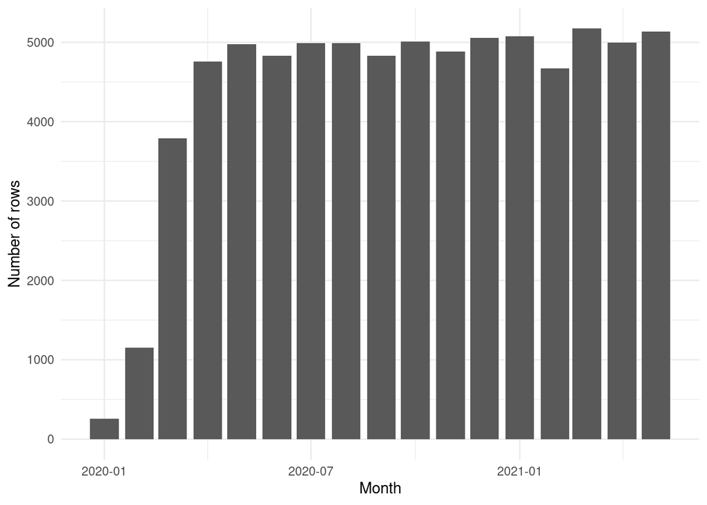

```r
data %>%
  mutate(year = as.numeric(substr(date, 1, 4)),
         month = as.numeric(substr(date, 6, 7)),
         newdate = as.Date(paste0(year, '-', month, '-', 1))) %>%
  count(newdate) %>%

  ggplot() +
  geom_col(aes(x = newdate, y = n)) +
  theme_minimal() +
  labs(y = 'Number of rows', x = 'Month') +
  theme(legend.position = 'None')
```

**The next plot shows the number of rows per country and month with strong vertical jitter and low alpha. We once again see, that for many countries we really have a very stable amount of entries from April 2020 until April 2021. There are many implicitly missing values at the beginning of the pandemic though.**

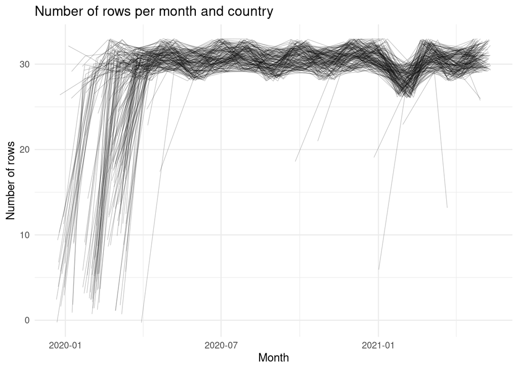

```r
data %>%
  mutate(year = as.numeric(substr(date, 1, 4)),
         month = as.numeric(substr(date, 6, 7)),
         newdate = as.Date(paste0(year, '-', month, '-', 1))) %>%
  count(location, newdate) %>%

  ggplot() +
  geom_line(aes(x = newdate, y = n, by = location), position = position_jitter(height = 2), size = .2, alpha = .3) +
  theme_minimal() +
  labs(y = 'Number of rows', x = 'Month') +
  ggtitle('Number of rows per month and country') +
  theme(legend.position = 'None')
```

# 5 Infections

```r
infection_data <- data %>% select(location, date, all_of(infection_columns))
```

## 5.1 Missing Values

**The first (collection of) plot(s) show(s) that all infection related features have about the same amount of missing values for all dates, except for the smoothed variants at the beginning of the pandemic, which makes a lot of sense.** **The begin of the pandemic is not very relevant anyway.**

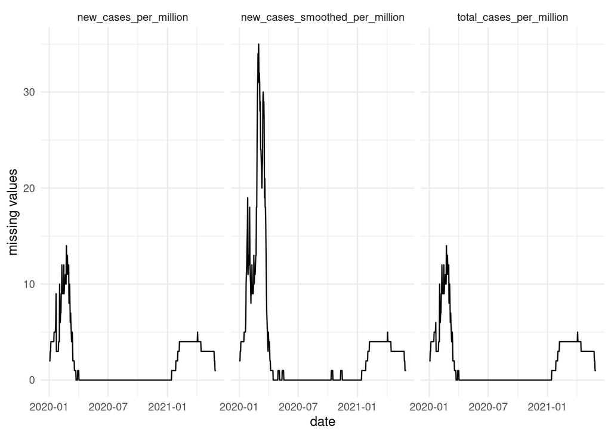

```r
plot_missing_by_date(infection_data, infection_columns)
```

**To have a little more context (black line…maximum possible missing values): Also makes a lot of sense and again shows that the date is reliable (not full of missing values) from approximately April 2020 to April 2021.**

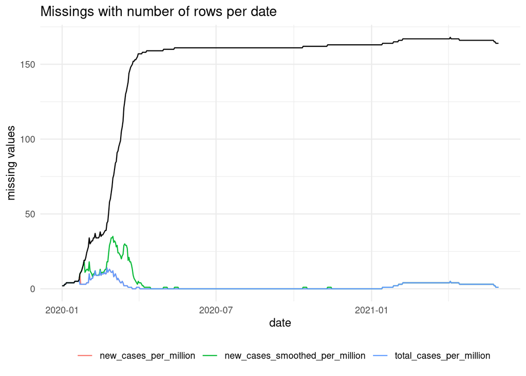

```r
plot_missing_by_date_context(infection_data, infection_columns)
```

**Last but not least, we have a look at the 10 countries with the most missing values (in absolute counts) in the infection columns. This means that there are rows for these countries but the respective infection columns are not filled.**

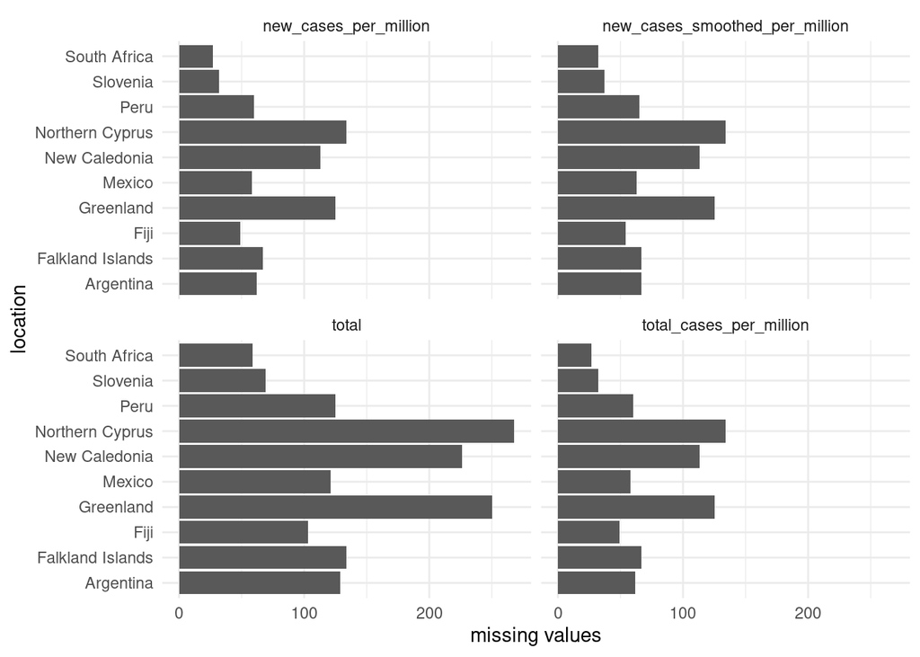

```r
plot_missing_by_country(infection_data, infection_columns)
```

```r
show_transitions(infection_data, infection_columns)
```

```
## # A tibble: 1 x 5
## # Groups:   location [1]
##   location date       total_cases_per_mi… new_cases_per_mi… new_cases_smoothed_…
##   <chr>    <date>                   <dbl>             <dbl>                <dbl>
## 1 Sudan    2020-03-13                   0                 0                    1
```

## 5.2 Values

**Some massive negative values here since values were corrected in hindsight I guess. They also appear in the smoothed variable where they are not so extreme though. Implicitly they also appear in the total cases! (i.e. total cases not monotonically increasing) It will make sense to use the smoothed variable for new cases after setting negative values to zero.**

```r
summary(infection_data)
```

```
##    location              date            total_cases_per_million
##  Length:74575       Min.   :2020-01-01   Min.   :     0.0
##  Class :character   1st Qu.:2020-06-24   1st Qu.:   204.8
##  Mode  :character   Median :2020-10-17   Median :  1435.8
##                     Mean   :2020-10-15   Mean   : 10914.7
##                     3rd Qu.:2021-02-09   3rd Qu.: 10622.4
##                     Max.   :2021-05-31   Max.   :158619.7
##                                          NA's   :943
##  new_cases_per_million new_cases_smoothed_per_million
##  Min.   :-5160.525     Min.   :-276.825
##  1st Qu.:    0.401     1st Qu.:   1.265
##  Median :    8.159     Median :  10.509
##  Mean   :   71.272     Mean   :  71.537
##  3rd Qu.:   67.440     3rd Qu.:  75.055
##  Max.   : 9760.898     Max.   :1536.030
##  NA's   :949           NA's   :1764
```

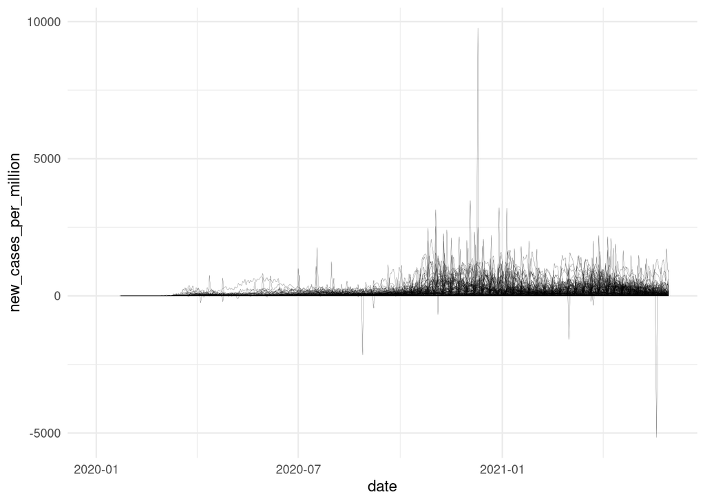

```r
plot_variable(infection_data, "new_cases_per_million")
```

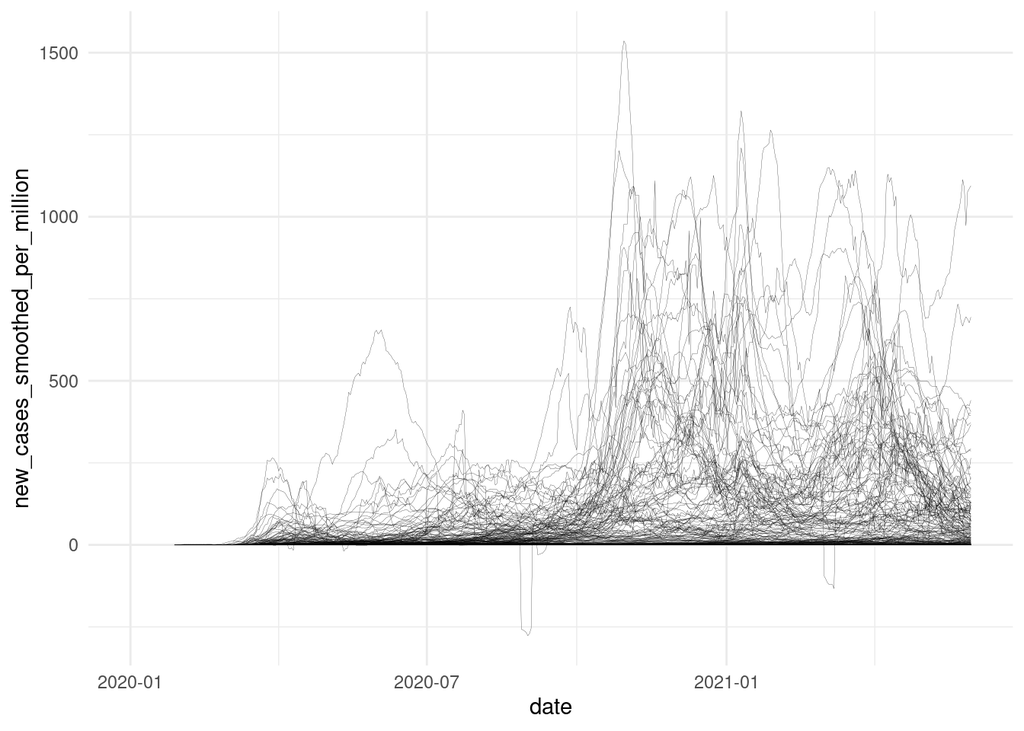

```r
plot_variable(infection_data, "new_cases_smoothed_per_million")
```

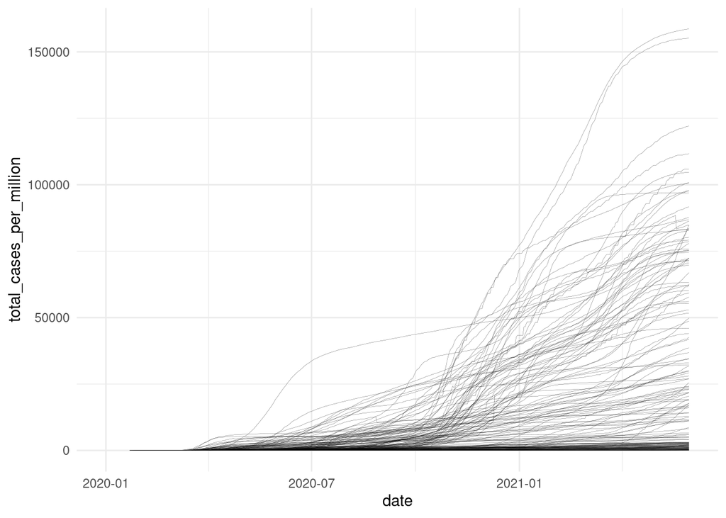

```r
plot_variable(infection_data, "total_cases_per_million")
```

# 6 Deaths

```r
death_data <- data %>% select(location, date, all_of(death_columns))
```

## 6.1 Missing Values

**The smoothed column globally looks more promising in terms of missing values here. Total and new deaths behave similarly.**

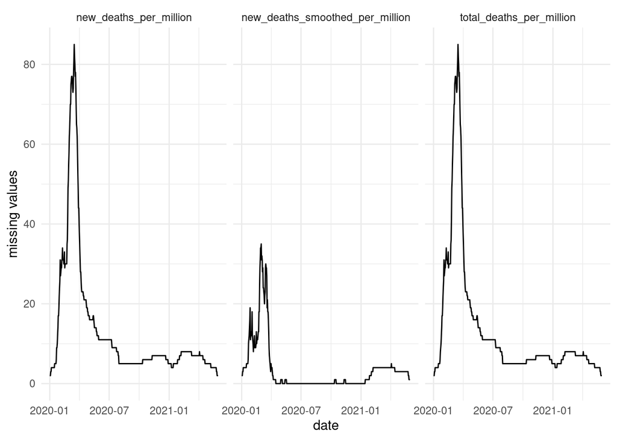

```r
plot_missing_by_date(death_data, death_columns)
```

**To have a little more context: Also makes a lot of sense and again shows that the date is reliable (not full of missing values) from approximately April 2020 to April 2021.**

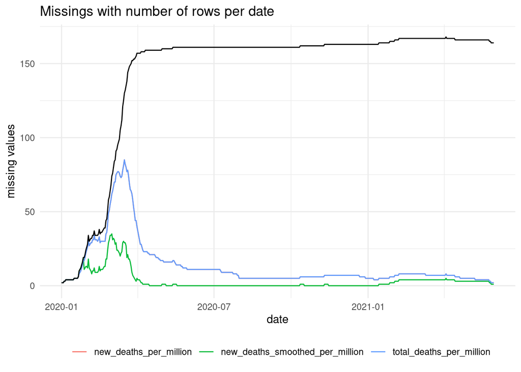

```r
plot_missing_by_date_context(death_data, death_columns)
```

**Last but not least, we have a look at the 10 countries with the most missing values (in absolute counts) in the death columns. This means that there are rows for these countries but the respective infection columns are not filled.**

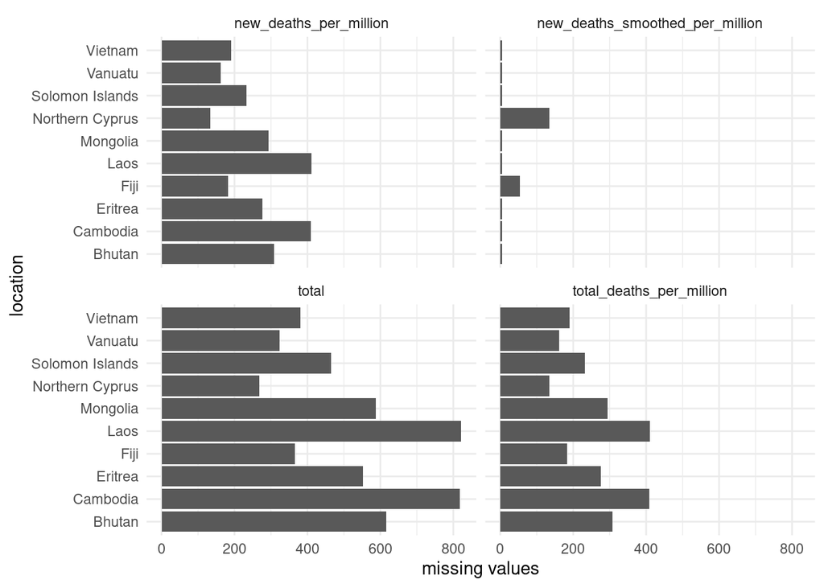

```r
plot_missing_by_country(death_data, death_columns)
```

**There is again one possible data error for Sudan (missing value following a non-missing value in March 2020).**

```r
show_transitions(death_data, death_columns)
```

```
## # A tibble: 1 x 5
## # Groups:   location [1]
##   location date       new_deaths_smoothed_… total_deaths_per_… new_deaths_per_m…
##   <chr>    <date>                     <dbl>              <dbl>             <dbl>
## 1 Sudan    2020-03-13                     1                  0                 0
```

## 6.2 Values

**There are again negative values for the non-total variables. The situation is similar as before with the infection variables.**

```r
summary(death_data)
```

```
##    location              date            new_deaths_smoothed_per_million
##  Length:74575       Min.   :2020-01-01   Min.   :-9.656
##  Class :character   1st Qu.:2020-06-24   1st Qu.: 0.008
##  Mode  :character   Median :2020-10-17   Median : 0.173
##                     Mean   :2020-10-15   Mean   : 1.362
##                     3rd Qu.:2021-02-09   3rd Qu.: 1.296
##                     Max.   :2021-05-31   Max.   :33.838
##                                          NA's   :1764
##  total_deaths_per_million new_deaths_per_million
##  Min.   :   0.001         Min.   :-67.901
##  1st Qu.:   6.650         1st Qu.:  0.000
##  Median :  39.678         Median :  0.154
##  Mean   : 239.112         Mean   :  1.475
##  3rd Qu.: 249.013         3rd Qu.:  1.350
##  Max.   :3077.839         Max.   :218.329
##  NA's   :6872             NA's   :6873
```

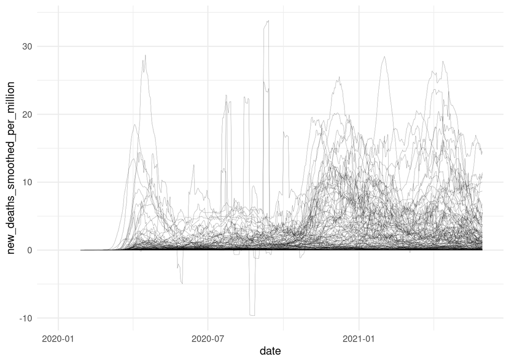

```r
plot_variable(death_data, "new_deaths_smoothed_per_million")
```

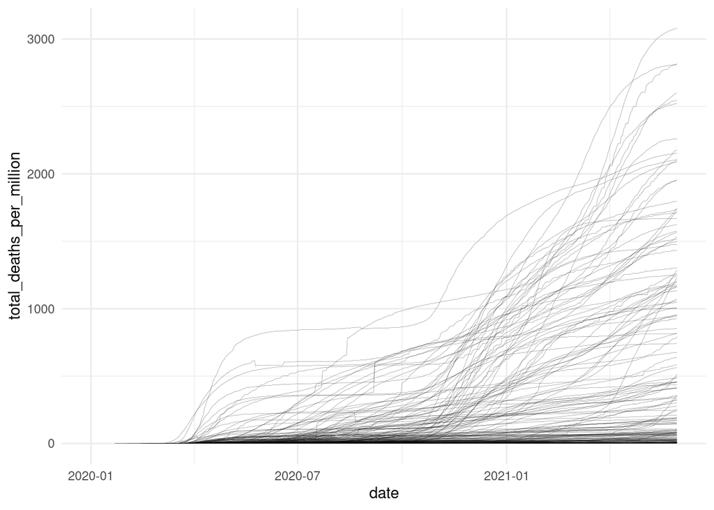

```r
plot_variable(death_data, "total_deaths_per_million")
```

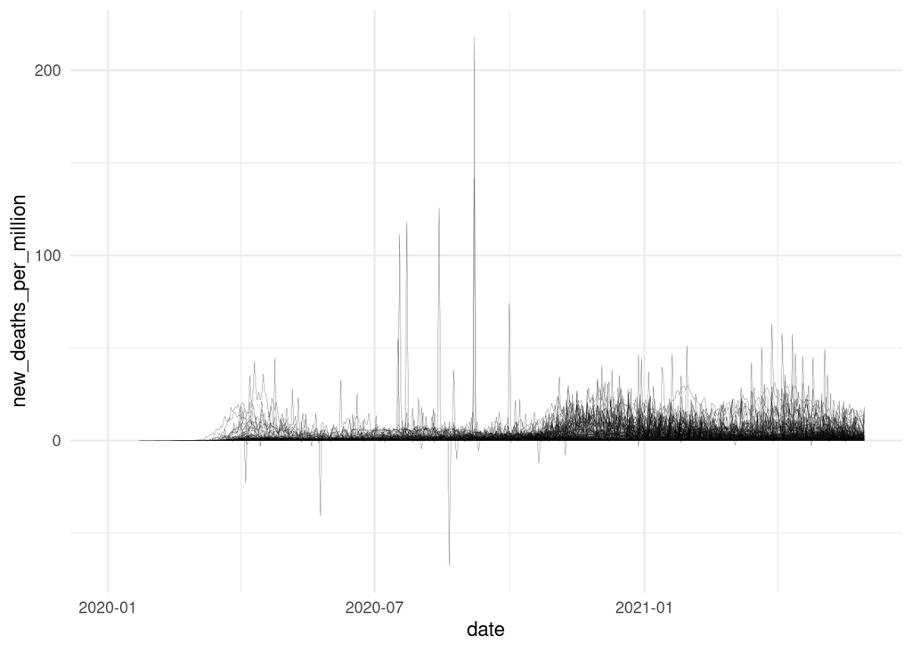

```r
plot_variable(death_data, "new_deaths_per_million")
```

# 7 Vaccinations

```r
vaccination_data <- data %>% select(location, date, all_of(vaccination_columns))
```

## 7.1 Missing Values

**Naturally, the vaccination columns just have NAs (approximately) until the end of 2020 (when the first vaccination campaigns started). Interestingly, the smoothed variables have far less NAs than the other variables. Having a closer look at the data, one can find out that the other columns have gaps while the smoothed variables kind of “interpolate” the vaccination numbers which leads to much less missing values.**

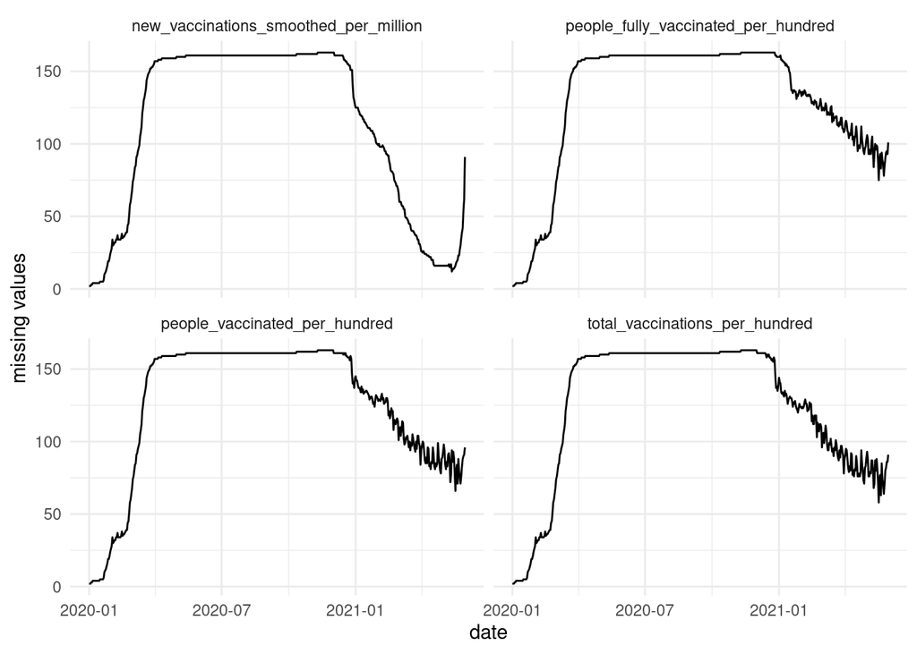

```r
plot_missing_by_date(vaccination_data, vaccination_columns) # day level
```

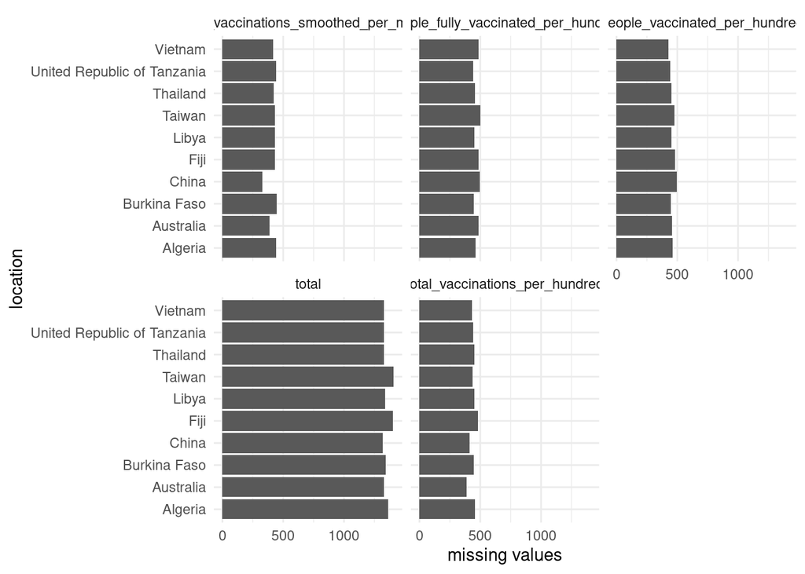

```r
plot_missing_by_country(vaccination_data, vaccination_columns, max_plot = 10) # top 10 (but similar for most countries)
```

**It is often the case that the total_vaccinations_per_hundred column has an NA following a non-missing value! We have to impute these values somehow in preprocessing. For the new vaccinations smoothed column the last days of the record are missing. Here we can simply fill them with the last available value.**

```r
show_transitions(vaccination_data, vaccination_columns)
```

```
## # A tibble: 1,550 x 6
## # Groups:   location [148]
##    location  date       total_vaccination… people_vaccinated… people_fully_vacc…
##    <chr>     <date>                  <dbl>              <dbl>              <dbl>
##  1 Afghanis… 2021-02-23                  1                  1                  0
##  2 Afghanis… 2021-03-01                  1                  1                  0
##  3 Afghanis… 2021-03-17                  1                  1                  0
##  4 Afghanis… 2021-04-08                  1                  1                  0
##  5 Afghanis… 2021-04-23                  1                  1                  0
##  6 Afghanis… 2021-05-12                  1                  1                  1
##  7 Afghanis… 2021-05-21                  1                  1                  1
##  8 Afghanis… 2021-05-25                  1                  1                  1
##  9 Afghanis… 2021-05-28                  1                  1                  1
## 10 Afghanis… 2021-05-31                  1                  1                  1
## # … with 1,540 more rows, and 1 more variable:
## #   new_vaccinations_smoothed_per_million <dbl>
```

```r
show_transitions(vaccination_data, "total_vaccinations_per_hundred")
```

```
## # A tibble: 1,512 x 6
## # Groups:   location [147]
##    location  date       total_vaccination… people_vaccinated… people_fully_vacc…
##    <chr>     <date>                  <dbl>              <dbl>              <dbl>
##  1 Afghanis… 2021-02-23                  1                 NA                 NA
##  2 Afghanis… 2021-03-01                  1                 NA                 NA
##  3 Afghanis… 2021-03-17                  1                 NA                 NA
##  4 Afghanis… 2021-04-08                  1                 NA                 NA
##  5 Afghanis… 2021-04-23                  1                 NA                 NA
##  6 Afghanis… 2021-05-12                  1                 NA                 NA
##  7 Afghanis… 2021-05-21                  1                 NA                 NA
##  8 Afghanis… 2021-05-25                  1                 NA                 NA
##  9 Afghanis… 2021-05-28                  1                 NA                 NA
## 10 Afghanis… 2021-05-31                  1                 NA                 NA
## # … with 1,502 more rows, and 1 more variable:
## #   new_vaccinations_smoothed_per_million <dbl>
```

```r
show_transitions(vaccination_data, "new_vaccinations_smoothed_per_million")
```

```
## # A tibble: 83 x 6
## # Groups:   location [83]
##    location   date       total_vaccination… people_vaccinate… people_fully_vacc…
##    <chr>      <date>                  <dbl>             <dbl>              <dbl>
##  1 Afghanist… 2021-05-31                 NA                NA                 NA
##  2 Algeria    2021-02-20                 NA                NA                 NA
##  3 Armenia    2021-05-24                 NA                NA                 NA
##  4 The Baham… 2021-05-30                 NA                NA                 NA
##  5 Bangladesh 2021-05-31                 NA                NA                 NA
##  6 Belarus    2021-05-24                 NA                NA                 NA
##  7 Belize     2021-05-29                 NA                NA                 NA
##  8 Benin      2021-05-22                 NA                NA                 NA
##  9 Bhutan     2021-05-28                 NA                NA                 NA
## 10 Bosnia an… 2021-05-26                 NA                NA                 NA
## # … with 73 more rows, and 1 more variable:
## #   new_vaccinations_smoothed_per_million <dbl>
```

## 7.2 Values

**The total_vaccinations_per_hundred have a little less missing values than the other cumulative variables here and also a direct correspondence to the new_vaccinations_smoothed_per_million column which is why we will use these two.**

```r
summary(vaccination_data)
```

```
##    location              date            total_vaccinations_per_hundred
##  Length:74575       Min.   :2020-01-01   Min.   :  0.00
##  Class :character   1st Qu.:2020-06-24   1st Qu.:  1.29
##  Mode  :character   Median :2020-10-17   Median :  6.05
##                     Mean   :2020-10-15   Mean   : 14.87
##                     3rd Qu.:2021-02-09   3rd Qu.: 19.50
##                     Max.   :2021-05-31   Max.   :130.13
##                                          NA's   :64556
##  people_vaccinated_per_hundred people_fully_vaccinated_per_hundred
##  Min.   : 0.00                 Min.   : 0.00
##  1st Qu.: 1.16                 1st Qu.: 0.62
##  Median : 4.35                 Median : 2.56
##  Mean   : 9.97                 Mean   : 5.71
##  3rd Qu.:13.34                 3rd Qu.: 7.09
##  Max.   :75.57                 Max.   :59.30
##  NA's   :65313                 NA's   :67410
##  new_vaccinations_smoothed_per_million
##  Min.   :     0
##  1st Qu.:   235
##  Median :  1014
##  Mean   :  2232
##  3rd Qu.:  2951
##  Max.   :118759
##  NA's   :58024
```

**Here we do not have negative values. We can just fill the missing values with zeros which (in most cases) is also semantically correct.**

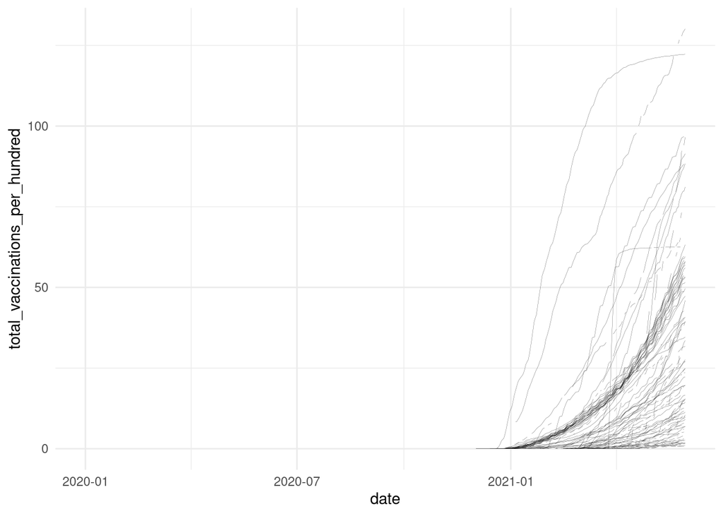

```r
ggplot(vaccination_data) +
  geom_line(aes(x = date, y = total_vaccinations_per_hundred, by = location), size = 0.05) +
  theme_minimal()
```

**There seem to be some outliers (Buthan and Falkland Islands) have more than 50000 new vaccinations/million, but since these are small countries it might just be correct**

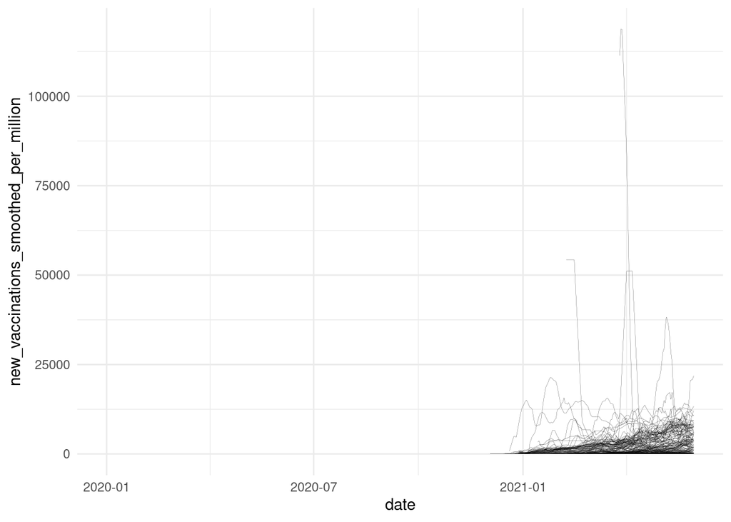

```r
ggplot(vaccination_data) +
  geom_line(aes(x = date, y = new_vaccinations_smoothed_per_million, by = location), size = 0.05) +
  theme_minimal()
```

# 8 Tests

```r
test_data <- data %>% select(location, date, all_of(test_columns))
```

## 8.1 Missing Values

**All columns behave similarly in terms of missing values. Smoothed has a little less missing values.**

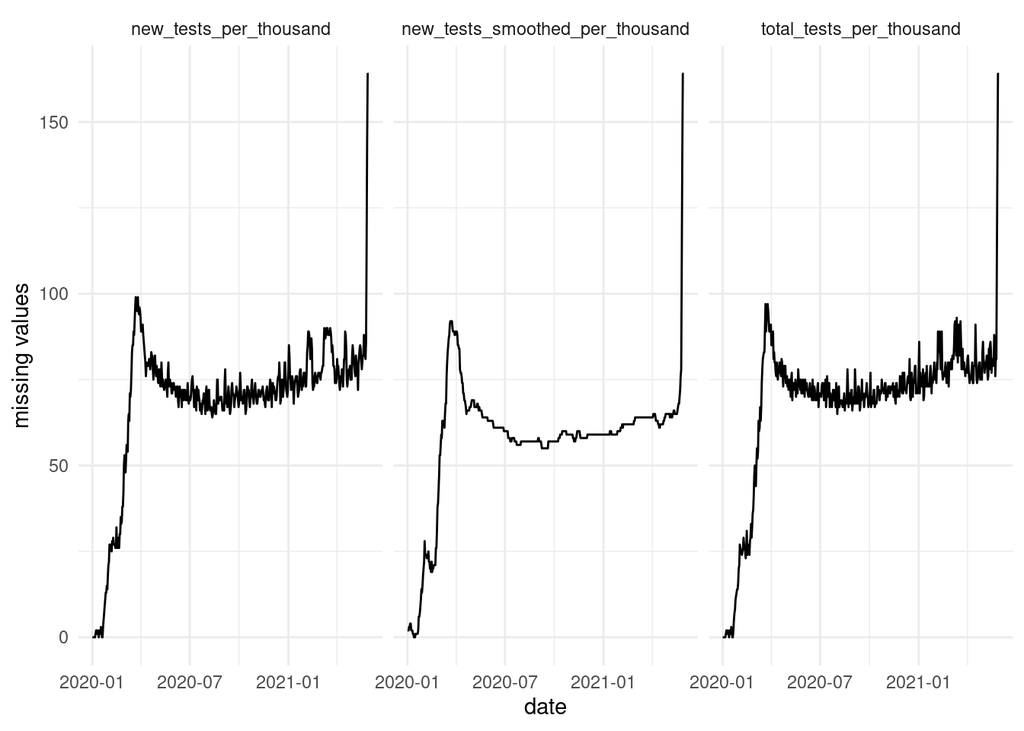

```r
plot_missing_by_date(test_data, test_columns)
```

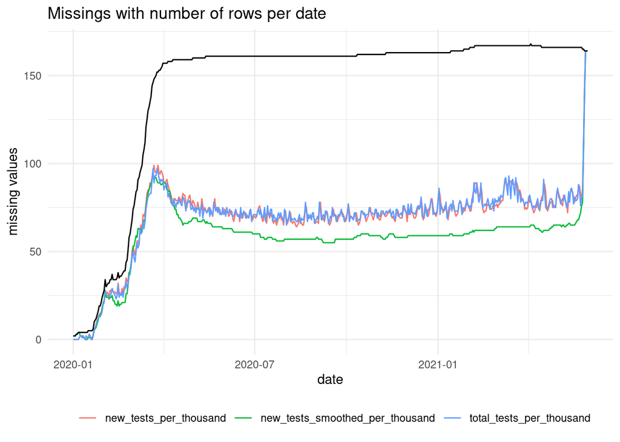

```r
plot_missing_by_date_context(test_data, test_columns)
```

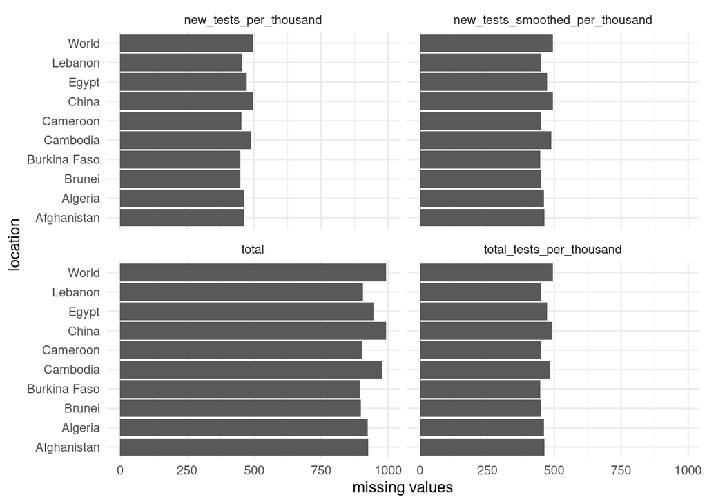

```r
plot_missing_by_country(test_data, test_columns)
```

```r
show_transitions(test_data, test_columns)
```

```
## # A tibble: 2,115 x 5
## # Groups:   location [120]
##    location  date       total_tests_per_t… new_tests_per_th… new_tests_smoothed…
##    <chr>     <date>                  <dbl>             <dbl>               <dbl>
##  1 Albania   2020-03-23                  1                 1                   0
##  2 Albania   2021-02-07                  1                 1                   0
##  3 Albania   2021-02-15                  1                 1                   0
##  4 Albania   2021-05-27                  1                 1                   1
##  5 Argentina 2020-01-08                  1                 1                   0
##  6 Argentina 2020-01-11                  1                 1                   0
##  7 Argentina 2020-01-14                  1                 1                   0
##  8 Argentina 2020-01-17                  1                 1                   0
##  9 Argentina 2020-01-21                  1                 1                   0
## 10 Argentina 2020-01-28                  1                 1                   0
## # … with 2,105 more rows
```

```r
show_transitions(test_data, "total_tests_per_thousand")
```

```
## # A tibble: 2,032 x 5
## # Groups:   location [114]
##    location  date       total_tests_per_t… new_tests_per_th… new_tests_smoothed…
##    <chr>     <date>                  <dbl>             <dbl>               <dbl>
##  1 Albania   2020-03-23                  1                NA               0.014
##  2 Albania   2021-02-07                  1                NA               1.25
##  3 Albania   2021-02-15                  1                NA               1.32
##  4 Albania   2021-05-27                  1                NA              NA
##  5 Argentina 2020-01-08                  1                NA               0.001
##  6 Argentina 2020-01-11                  1                NA               0.001
##  7 Argentina 2020-01-14                  1                NA               0
##  8 Argentina 2020-01-17                  1                NA               0
##  9 Argentina 2020-01-21                  1                NA               0
## 10 Argentina 2020-01-28                  1                NA               0
## # … with 2,022 more rows
```

```r
show_transitions(test_data, "new_tests_smoothed_per_thousand")
```

```
## # A tibble: 136 x 5
## # Groups:   location [117]
##    location  date       total_tests_per_t… new_tests_per_th… new_tests_smoothed…
##    <chr>     <date>                  <dbl>             <dbl>               <dbl>
##  1 Albania   2021-05-27                 NA                NA                   1
##  2 Argentina 2021-05-23                 NA                NA                   1
##  3 Armenia   2021-05-28                 NA                NA                   1
##  4 Australia 2021-05-29                 NA                NA                   1
##  5 Austria   2021-05-28                 NA                NA                   1
##  6 Azerbaij… 2021-05-29                 NA                NA                   1
##  7 Banglade… 2021-05-28                 NA                NA                   1
##  8 Belarus   2021-05-29                 NA                NA                   1
##  9 Belgium   2021-05-27                 NA                NA                   1
## 10 Belize    2021-05-28                 NA                NA                   1
## # … with 126 more rows
```

## 8.2 Values

**Only the unsmoothed new tests variable which we will not use anyway has negative values.**

```r
summary(test_data)
```

```
##    location              date            total_tests_per_thousand
##  Length:74575       Min.   :2020-01-01   Min.   :   0.00
##  Class :character   1st Qu.:2020-06-24   1st Qu.:  11.60
##  Mode  :character   Median :2020-10-17   Median :  56.14
##                     Mean   :2020-10-15   Mean   : 242.28
##                     3rd Qu.:2021-02-09   3rd Qu.: 224.82
##                     Max.   :2021-05-31   Max.   :7765.47
##                                          NA's   :35449
##  new_tests_per_thousand new_tests_smoothed_per_thousand
##  Min.   :-23.01         Min.   : 0.000
##  1st Qu.:  0.12         1st Qu.: 0.115
##  Median :  0.52         Median : 0.518
##  Mean   :  1.90         Mean   : 1.743
##  3rd Qu.:  1.68         3rd Qu.: 1.681
##  Max.   :327.09         Max.   :92.104
##  NA's   :35542          NA's   :29923
```

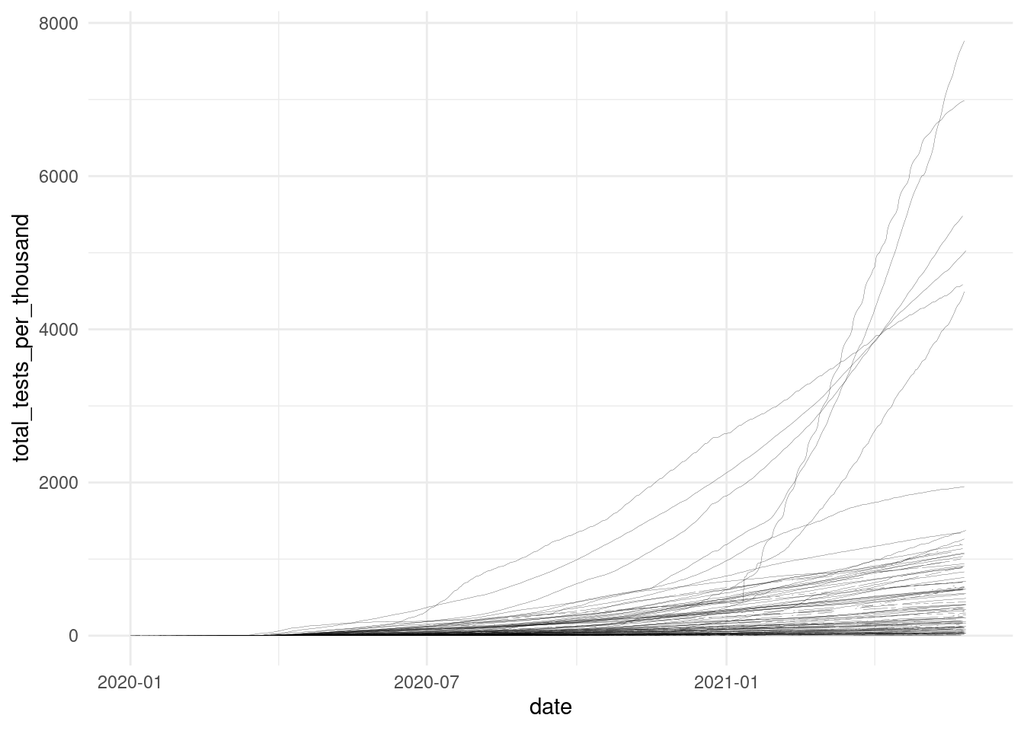

```r
plot_variable(test_data, "total_tests_per_thousand")
```

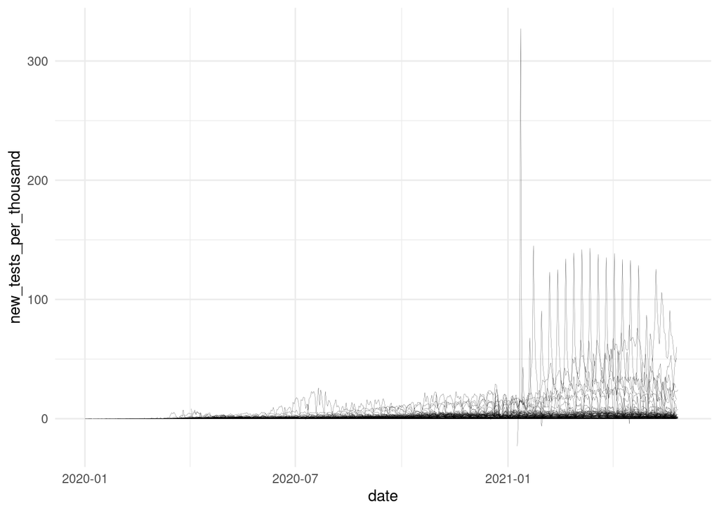

```r
plot_variable(test_data, "new_tests_per_thousand")
```

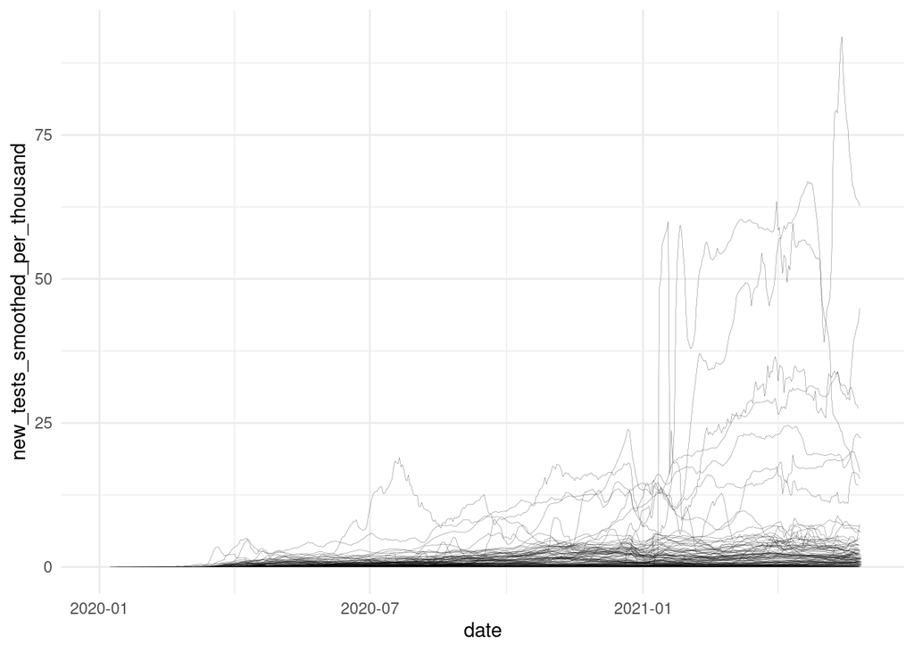

```r
plot_variable(test_data, "new_tests_smoothed_per_thousand")
```

# 9 Risk factors

**The risk factors seem to have no variation at all even though they are actually time-series, or at least naturally time-varying.**

```r
risk_factor_variances <- data %>%
  group_by(location) %>%
  summarise_all(var, na.rm = TRUE) %>%
  select(risk_factor_columns)

sum(risk_factor_variances, na.rm = TRUE)
```

```
## [1] 0
```

**Since these values are constant, we can (in case of missing values) just overwrite these missing values with the mean per country and impute 0 if there is not a single non-missing value per_country.**

```r
risk_factor_data <- data %>%
  select(location, date, all_of(risk_factor_columns))
```

```r
risk_factors_aggregated <- risk_factor_data %>%
  group_by(location) %>%
  summarise_at(risk_factor_columns, function(x) mean(x, na.rm = TRUE))

sapply(risk_factors_aggregated, function(x) sum(is.nan(x)))
```

```
##                   location     handwashing_facilities
##                          0                         80
## hospital_beds_per_thousand      cardiovasc_death_rate
##                         22                          4
##        diabetes_prevalence             female_smokers
##                          5                         39
##               male_smokers
##                         41
```

**This complicatedly seeming query finds out that the risk factors are actually either available for all entries of a country or not at all. I.e. we only have to set them to zero where they are not available at all.**

```r
risk_factor_data %>%
  group_by(location) %>%
  mutate(na_col = NA) %>%
  summarize_at(c("na_col", risk_factor_columns), function(x) sum(is.na(x))) %>%
  pivot_longer(cols = all_of(c("na_col", risk_factor_columns))) %>%
  filter(value > 0) %>%
  group_by(location) %>%
  summarize(n_unique = n_distinct(value)) %>%
  filter(n_unique > 1)
```

```
## # A tibble: 0 x 2
## # … with 2 variables: location <chr>, n_unique <int>
```

# 10 Facts

**The facts are just for the fact fields. We just need them aggregated, not in time-series format.**

```r
fact_variances <- data %>%
  group_by(location) %>%
  summarise_all(var, na.rm = TRUE) %>%
  select(risk_factor_columns)

sum(fact_variances, na.rm = TRUE)
```

```
## [1] 0
```

**Fortunately, they are also constant in the dataset. The few missing values can be just overwritten with ‘unknown’ and we can export them as strings since we only write them into the fact fields without doing any computation. (Javascript is weakly typed however)**

```r
fact_data <- data %>%  select(location, date, all_of(fact_columns))
```

```r
facts_aggregated <- fact_data %>%
  group_by(location) %>%
  summarise_at(fact_columns, function(x) mean(x, na.rm = TRUE))

sapply(facts_aggregated, function(x) sum(is.nan(x)))
```

```
##        location      population  gdp_per_capita      median_age life_expectancy
##               0               1               8               4               2
```

```r
fact_data %>%
  group_by(location) %>%
  mutate(na_col = NA) %>%
  summarize_at(c("na_col", fact_columns), function(x) sum(is.na(x))) %>%
  pivot_longer(cols = all_of(c("na_col", fact_columns))) %>%
  filter(value > 0) %>%
  group_by(location) %>%
  summarize(n_unique = n_distinct(value)) %>%
  filter(n_unique > 1)
```

```
## # A tibble: 0 x 2
## # … with 2 variables: location <chr>, n_unique <int>
```

# 11 Sources

- https://cran.r-project.org/web/packages/naniar/vignettes/naniar-visualisation.html
- https://tidyr.tidyverse.org/reference/pivot_longer.html
- https://www.datanovia.com/en/blog/ggplot-axis-ticks-set-and-rotate-text-labels/
- http://www.sthda.com/english/wiki/ggplot2-rotate-a-graph-reverse-and-flip-the-plot
- https://stackoverflow.com/questions/10866047/jitter-geom-line